# Coursework Report

*N* removed NAs: 3

*N* removed typo: 1

*N* removed <18: 27

*N* total clean: 119

| Group | *N* | *M*<sub>age</sub> | *M*<sub>rating</sub> |
| --- | --- | --- | --- |
| Control | 57 | 21.1 | 5.89 |
| Experim | 62 | 20.6 | 6.89 |

**Main analysis results**

*t*(117) = -7.29, *p* < .001

[interactive chart not shown]

[figure not shown]

[interactive chart not shown]

# Coursework Report

Analysing Data, Spring 2020

# Methods

## Participants

The experiment initially had 150 participants with a mean age of 19.8, however this was greatly skewed due to an anomalous data value of ‘1y’ which was assumed to be, and adjusted to 1 years old. For ethical reasons all participants under the age of 18 years old were removed, in turn removing the anomalous ‘1’ year old participant. With the anomalous data removed, and participants under 18 removed we were left with 119 participants, with a mean age of 20.86 years, with a minimum age of 18, a maximum age of 26, and an SD of 1.97. Table 1 shows the mean, the SD, and the minimum and maximum age in each condition.

*Table 1: Summary of age descriptives by condition*

| Condition | *N* | *M*<sub>age</sub> | *SD* | *Min*<sub>Age</sub> | *Max*<sub>Age</sub> |
| --- | --- | --- | --- | --- | --- |
| control | 57 | 21.1 | 1.86 | 18 | 26 |
| experimental | 62 | 20.6 | 2.04 | 18 | 26 |

## Design

For this experiment, our conceptual hypothesis was ‘Does viewing red lead women to perceive men as more attractive?’ The experiment used an independent measures design. Our independent variable was the colour of the frame around a black and white photograph of a man. Our independent variable is categorical and has two levels, a red frame being our experimental condition, and a white frame being our control. Our dependent variable was the rated attractiveness, a continuous variable, which was valued on a scale going from 1 being lowest attractiveness, to 9 being highest attractiveness (1 - 9). This rating scale was based on 3 face-valid items directed at the participant upon viewing the photograph in either frame. The items were: “How attractive do you think this person is?” “How pleasant is this person to look at?” “If I were to meet the person in this picture face to face, I would think he is attractive.” Our operational hypothesis was: Does viewing a different colour frame around an image of a moderately attractive man influence the mean ratings of his attractiveness? This hypothesis will be tested using a t test.

# Results

*Table 2: Summary of mean composite ratings by condition*

| Condition | **N** | *Mean* comp<sub>rating</sub> | *SD* comp<sub>rating</sub> | *Median* comp<sub>rating</sub> |
| --- | --- | --- | --- | --- |
| control | 57 | 6 | 1.15 | 6.00 |
| experimental | 62 | 7 | 1.05 | 6.83 |

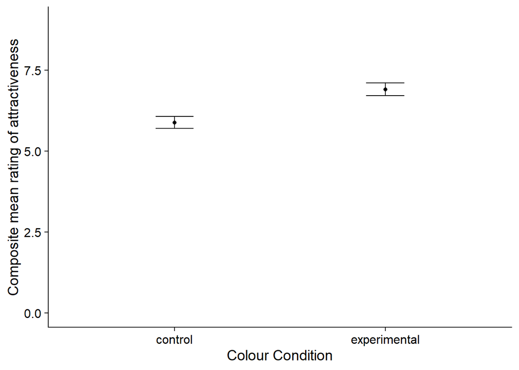

Figure 1. The difference in composite mean rating of attractiveness by colour condition

# Discussion

In this replication of Elliot’s original study (Elliot et al., 2010) a significant effect was found in which participants in the experimental ‘red condition’ rated the man as more attractive than participants in the control ‘white condition’; thus supporting the hypothesis and in turn supporting the findings in Elliot’s study that the colour red causes women to perceive men as more attractive. However, although the effect is indeed present, and the difference in ratings is significant, it could be argued it is only relatively small, with just one rating point between the two composite scores.

When comparing the results of our replication to Elliot’s original findings, it is important to consider the accusations of publication bias that the study received. (Francis, 2013) Francis’ paper details the lack of power in Elliots study and suggests that null results were either omitted entirely or that there was improper practise in the running of the experiments. Francis himself states ‘It remains an open question whether the color red influences women’s ratings of men’s attributes.’ (Francis, 2013) demonstrating the vital importance of replications such as ours in properly verifying or disproving previous findings in the research. It’s noteworthy that these accusations were then addressed in Elliot & Maier’s, 2013 paper, providing several examples of supporting evidence from other research studies of this ‘red attractiveness effect’, even going on to produce their own supporting replication. (Elliot & Maier, 2013) Elliot and Maier’s paper competently emphasises the significance of replications in research.

As valid as it is to discuss supporting replications, it is equally as important to look at the replications that found opposing findings to Elliot et al., 2010. In Hesslinger’s replication study ‘Men in red: A reexamination of the red-attractiveness effect’ (Hesslinger et al., 2015) there was no significant effect found, nor was a significant effect found in their expanded adaptation of Elliot’s study. The replication used a larger sample, but still found no significant effect. This is noteworthy as a key criticism by Francis was the lack of power in findings which Elliot suggested would be solved by a larger, ‘more powerful sample’. (Elliot & Maier, 2013) Hesslingers findings seem to refute this claim. In Hesslingers adapated secondary experiment they found that apparel styles were a more significant predictor of attractiveness ratings. (Hesslinger et al., 2015) With this in mind, it is important to consider other studies that have found other variables to be more significant than the red effect.

One study ‘The red-derogation effect: How the color red affects married women’s ratings of male attractiveness’ (Pontes & Hoegg, 2019) presents various findings in their study that are worth considering when interpreting our own results. In the study photos of 21 different men of varying ethnicity were used (Unlike in the Elliot study where just the one photo of the same man was used.) shown with either a white or red frame. Participants in the study were then asked to rate the males attractiveness on a 9 point rating scale.

One effect worth considering was the influence of ethnicity bias in attraction. This ethnicity bias effect was found to be statistically significant as Caucasians rated other Caucasians as more attractive than non-Caucaisans. (Pontes & Hoegg, 2019) The implications of these findings for our own study are that as we have no data on the ethnicity of our participants we cannot be sure if our results are skewed by ethnicity bias or not. This is a very possible extraneous variable to our data and in any future replications it would be important to control for this bias. A further element is that in Pontes & Hoeggs findings was that though relationship status did not have a significant effect on attractiveness ratings, there was a significant interaction effect between relationship status and ethnicity in that Caucasian men were rated as more attractive by Caucasian women that were single, than Caucasian women that were married. Additionally the study found that relationship status also seemed to have an interaction in effect with the colour of the frame as single women significantly rated men as more attractive when in conjunction with a red colour frame, and married women rated the men as less attractive when shown with a red frame, rather than the white frame.

The ‘derogation effect’ is a ‘relationship maintenance mechanism’ (Pontes & Hoegg, 2019) in which individuals in a relationship will rate members of the opposite sex as less attractive. Pontes & Hoegg made a prediction that the red effect shown in studies such as Elliot’s, would cause what they termed a ‘red derogation effect’. (Pontes & Hoegg, 2019) Their findings were shown to support this prediction. These findings suggest that relationship status is an important factor to control for in this area of research, which is another variable in our study that we did not control.

In conclusion, based on our own research and other published research, I would argue that the colour red does have some effect on perceived attractiveness. However it is vital to consider the multitude of other extraneous factors that can influence perceived attractiveness when trying to observe this ‘red effect’ as attractiveness is clearly a multi faceted phenomenon. These other factors may be far more significant and over shadow any effect the ‘red effect’ may have. Due to this I would strongly suggest that any future research controls for factors such as ethnicity, relationship status, and apparel.

# References

Elliot, A. J., Niesta Kayser, D., Greitemeyer, T., Lichtenfeld, S., Gramzow, R. H., Maier, M. A., & Liu, H. (2010). Red, rank, and romance in women viewing men. Journal of Experimental Psychology: General, 139(3), 399–417. https://doi.org/10.1037/a0019689

Francis, G. (2013). Publication bias in “Red, rank, and romance in women viewing men,” by Elliot et al. (2010). Journal of Experimental Psychology: General, 142(1), 292–296. https://doi.org/10.1037/a0027923

Elliot, A. J., & Maier, M. A. (2013). The red-attractiveness effect, applying the Ioannidis and Trikalinos (2007b) test, and the broader scientific context: A reply to Francis (2013). Journal of Experimental Psychology: General, 142(1), 297–300. https://doi.org/10.1037/a0029592

Hesslinger, V. M., Goldbach, L., & Carbon, C.-C. (2015). Men in red: A reexamination of the red-attractiveness effect. Psychonomic Bulletin & Review, 22(4), 1142–1148. https://doi.org/10.3758/s13423-015-0866-8

Pontes, N., & Hoegg, J. (2019). The red-derogation effect: How the color red affects married women’s ratings of male attractiveness. Journal of Experimental Psychology: Applied. https://doi.org/10.1037/xap0000256